# Week 3 Assignment

Hsin-Yi Chien

2022-10-02

# FY22 COVES Annual Report

Visitor Research and Evaluation (VRE) collected exit surveys between *July 1, 2021 and June 30, 2022* to gain a better understanding of our **visitor demographics** and **visitor experience** during their visit to the Exploratorium.

## Group Demographics

The COVES protocol involves selecting one adult from a visitor group to be the primary respondent, but the survey asks for some information that describes *the entire visiting group*.

### Group Size

According to all the respodents who provided information regarding the number of adults and child(ren) in their visiting group:

- **Average group size** = 3.19
- **Median group size** = 3
- **Average** number of *adults* in a group = 2.21
- **Median** number of *adults* in a group = 2
- **Average** number of *children* in a group = 0.98
- **Median** number of *children* in a group = 1

```r
#Create a new var "group_size" by taking the sum of Nchild and Nadults in a group
for (i in (1:nrow(coves_fy22))){
  coves_fy22$group_size[i] <- sum(coves_fy22$Nadults[i], coves_fy22$Nchild[i],
                                  na.rm = TRUE)
}

#Select rows that do not have any missing data on Nadults and Nchild & select Nadults, Nchild, and #group_size cols. Save the subset as "coves_fy_groupsize" df.

coves_fy22_groupsize <- coves_fy22 %>%
  drop_na(Nadults, Nchild) %>%
  select(Nadults, Nchild, group_size) %>%
  arrange(desc(group_size))

coves_fy22_groupsize %>%
  summarize(mean_Nadults = round(mean(Nadults, na.rm = TRUE), 2),
            median_Nadults = round(median(Nadults, na.rm = TRUE), 2),
            mean_Nchild = round(mean(Nchild, na.rm = TRUE), 2),
            median_Nchild = round(median(Nchild, na.rm = TRUE), 2),
            mean_group_size = round(mean(group_size, na.rm = TRUE), 2),
            median_group_size = round(median(group_size, na.rm = TRUE), 2))
```

```
## # A tibble: 1 × 6
##   mean_Nadults median_Nadults mean_Nchild median_Nchild mean_group_size median…¹
##          <dbl>          <dbl>       <dbl>         <dbl>           <dbl>    <dbl>
## 1         2.21              2        0.98             1            3.19        3
## # … with abbreviated variable name ¹median_group_size
```

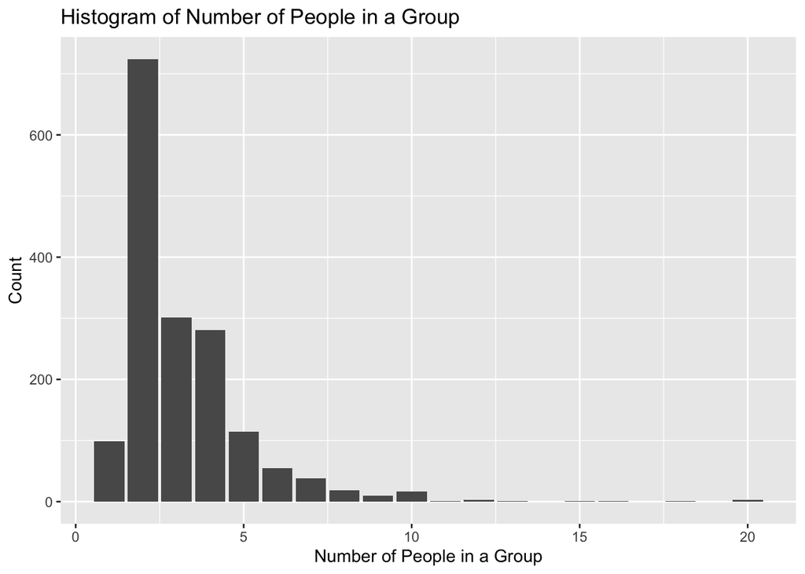

```r
hist_group_size <- coves_fy22_groupsize %>%
  ggplot(aes(x = group_size)) +
  geom_bar() +
  labs(title = "Histogram of Number of People in a Group")+
  xlab("Number of People in a Group") +
  ylab("Count")

hist_group_size
```

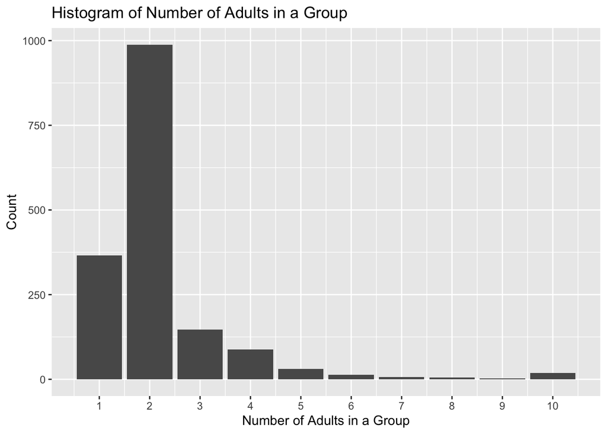

```r
hist_Nadults <- coves_fy22_groupsize %>%
  ggplot(aes(x = Nadults)) +
  geom_bar() +
  scale_x_continuous(breaks = seq(0:10))+
  labs(title = "Histogram of Number of Adults in a Group")+
  xlab("Number of Adults in a Group") +
  ylab("Count")

hist_Nadults
```

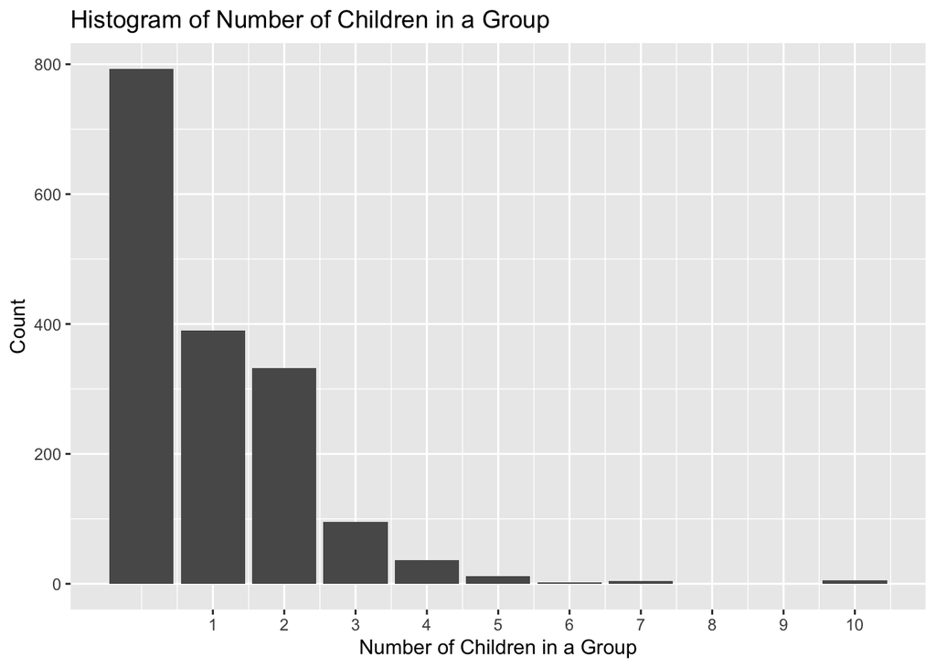

```r
hist_Nchild <- coves_fy22_groupsize %>%
  ggplot(aes(x = Nchild)) +
  geom_bar() +
  scale_x_continuous(breaks = seq(0:10))+
  labs(title = "Histogram of Number of Children in a Group")+
  xlab("Number of Children in a Group") +
  ylab("Count")

hist_Nchild
```

## Overall Experience Rating

Among respondents who provided an overall experience rating:

- **48.2%** rated their experience as *Outstanding*
- **43.3%** rated their experience as *Excellent*
- **8.5%** rated their experience as less than excellent

```r
#add labels to OER
coves_fy22$OER<-factor(coves_fy22$OER,
                       levels = c(1,2,3,4,5),
                       labels = c("Poor", "Fair", "Good", "Excellent", "Outstanding"),
                       ordered = TRUE)

#show the frequency of OER
coves_fy22 %>%
  drop_na(OER) %>%
  tabyl(OER) %>%
  adorn_totals() %>%
  adorn_pct_formatting(digits = 1,
                       rounding = "half up")
```

```
##          OER    n percent
##         Poor    1    0.1%
##         Fair   12    0.6%
##         Good  151    7.8%
##    Excellent  844   43.3%
##  Outstanding  939   48.2%
##        Total 1947  100.0%
```

The following shows the breakdown of Overall Experience Rating by Group Type (Adult-only vs. Family Group):

```r
#create a "group type" var based on whether there is any children in the group
for (i in (1:nrow(coves_fy22))){
  if (is.na(coves_fy22$Nchild[i])){
    coves_fy22$group_type[i] <- NA
  } else if (!is.na(coves_fy22$Nchild[i]) & coves_fy22$Nchild[i] == 0){
    coves_fy22$group_type[i] <-"Adult Only"
  } else if (!is.na(coves_fy22$Nchild[i]) & coves_fy22$Nchild[i] > 0){
    coves_fy22$group_type[i] <-"Family Group with Child(ren)"
  }
}

#check if the above scripts are successful
coves_fy22 %>%
  select(Nchild, group_type)
```

```
## # A tibble: 1,950 × 2
##    Nchild group_type
##     <dbl> <chr>
##  1      1 Family Group with Child(ren)
##  2      2 Family Group with Child(ren)
##  3     NA <NA>
##  4      3 Family Group with Child(ren)
##  5      0 Adult Only
##  6      3 Family Group with Child(ren)
##  7      3 Family Group with Child(ren)
##  8      0 Adult Only
##  9      0 Adult Only
## 10     NA <NA>
## # … with 1,940 more rows
```

```r
#show the frequency of OER by group_type
coves_fy22 %>%
  drop_na(OER, group_type) %>%
  tabyl(OER, group_type) %>%
  adorn_totals(where = c("row", "col")) %>%
  adorn_percentages("col") %>%
  adorn_pct_formatting(digits = 1,
                       rounding = "half up") %>%
  adorn_ns()
```

```
##          OER   Adult Only Family Group with Child(ren)         Total
##         Poor   0.0%   (0)                   0.0%   (0)   0.0%    (0)
##         Fair   0.6%   (5)                   0.1%   (1)   0.4%    (6)
##         Good   7.8%  (62)                   5.9%  (52)   6.8%  (114)
##    Excellent  44.1% (349)                  42.1% (370)  43.0%  (719)
##  Outstanding  47.5% (376)                  51.9% (456)  49.8%  (832)
##        Total 100.0% (792)                 100.0% (879) 100.0% (1671)
```